# SDS Homework 1

Marco Muscas, Marina Iuliana Aur, Laura Thoft Cesario, Livia Oddi

November 2023

Before we forget, let’s set a seed.

```r
set.seed(112023)
```

# Introduction

## 1.1- Flipping coins!

### The setup

As stated in the exercise, we will be playing as the professor of a class of $n = 150$ students. Out of these $n$ students we *know* that there are exactly $k$ non-honest students, leaving $(n-k)$ honest ones. It will be our job to tell them apart, by flipping coins!

We know that: * the $(n-k)$ honest students will use a fair coin, therefore the probability of a success (let’s say, getting `heads`) is the same as getting `tails`, $p = 0.5$. * the $k$ cheaters will use (of course) a trick coin, of a given probability chosen arbitrarily only constrained in being greater that $0.5$, hence $q > p$.

Also, to better tell them apart, we are constrained with letting them throw their respective coins $N$ times, again chosen arbitrarily.

### A first look at our data

By the setup we can already setup two random variables, which each assume values from repeated Bernoulli trials and counting the number of successes.

Let us write then:

| $X_H \sim \text{Binom}(N, p)$ | $H \in [1, (n-k)]$ |
| --- | --- |
| $X_L \sim \text{Binom}(N, q)$ | $L \in [1, k]$ |

First, we have to set the various variables!

```r
N = 100  # Number of throws         - It's FIXED but variable, we are the prof afterall
n = 150  # Total number of students
k = 70   # liars
(n - k)  # The remaining honest ones
```

```
## [1] 80
```

```r
p = 0.5
q = 0.65
```

Let us take a look at the two distribution! We expect them to follow two Binomials, each centered in $N\cdot p$ and $N\cdot q$ respectively.

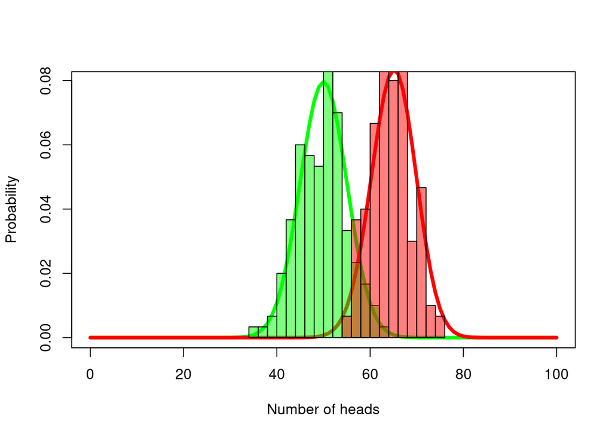

## Decisional functions!

According to the setup, we have to make them throw coins *as long as it is necessary*, therefore we have to come up with a decision rule to “evaluate” the result of the tosses. The first one is given to us by example: **thresholding**.

We will need a *threshold* parameter, namely $\theta$ to check the proportion of heads (which we identify as a success). It’s simple:

```r
# Set the threshold theta
decision_rule = function(throws_vec, theta, N){
  is_liar = (throws_vec) > (N * theta)
  return (is_liar) # ... by our decision rule
}
```

To put it **simply**: if the number of successes (heads) is above $\theta \cdot N$ then we classify that person as a liar. Seems faulty, let’s see if this statement has any ground.

## A first simulation

We want to discover, for the given setup, what would be the results - meaning what quantities of *true positive* (TP), *true negative* (TN), *false positive* (FP), *false negative* (FN) we get for the given parameters and decision rule.

Side note : we will introduce a score function for our decision rule later on.

First off, let’s set the simulation size. We found the value below to be acceptable, though if you want more **stable** results just increase it by one or more orders of magnitude. This last statement is in accordance to the assumption that asymptotically a sample quantity of interest better approximates the underlying population quantity of interest - namely the true/negative rates.

Let us start:

```r
M = 1e2 # 1000, good enough!

# In our experiment we vary the thetas
num_thetas = 100 # So decide how many of them we want to test
theta_variations = seq(0.5, 1, length.out = num_thetas) # And set the threshold vector
```

Plus, we will analyze some additional *scores*, namely **accuracy**, **precision**, **recall** and **f-1 Score**. We should remember they are derived from the $TP, TN, FP, FN$, but they’re a low hanging fruit, so why not include them!

```r
rates = matrix(data = NA, nrow = num_thetas, ncol = 4) # Matrix where we'll register the TPR, FPR, TNR, FNR
scores = matrix(data = NA, nrow = num_thetas, ncol = 4)# Here we'll store accuracy, precision, recall, f1

for(idx in 1:num_thetas){

  theta = theta_variations[idx]
  rates_sim = matrix(data = NA, nrow = M, ncol = 4)
  scores_sim = matrix(data = NA, nrow = M, ncol = 4)

  for(m in 1:M){

    # Simulate the throws!
    honest_throws = rbinom(n = (n - k), size = N, prob = p)
    liar_throws = rbinom(n = k, size = N, prob = q)

    # The 1 * Boolean evaluates to an integer, which in our mind is easier
    # to work with. Just a matter of preference :)
    classification_H = 1 * decision_rule(honest_throws, theta, N)
    classification_L = 1 * decision_rule(liar_throws, theta, N)

    # false positive -> (the student is apparently a liar | the student is actually honest)
    # false negative -> (the student is apparently honest | the student is actually a liar)

    tp = sum(classification_H == 0) # In the Honest students vector, which were classified as NOT LIAR? (0)
    fp = sum(classification_H == 1)
    tn = sum(classification_L == 1)
    fn = sum(classification_L == 0)

    tp_rate = tp / (n) # Calculate the rates wrt the population
    fp_rate = fp / (n) # for all of the various scores
    tn_rate = tn / (n)
    fn_rate = fn / (n)


    # The low-hanging fruits. Why not!
    accuracy = (tn + tp)/n
    precision = tp / (tp + fp)
    recall = tp / (tp + fn)
    f1 = 2 * (precision * recall)/(precision + recall)

    rates_sim[m,] =  c(tp_rate, tn_rate, fp_rate, fn_rate)
    scores_sim[m, ] =c(accuracy, precision, recall, f1)
  }


  # Each row is a different theta, in the columns their "performance"
  tp_rates_mean = mean(rates_sim[,1])
  tn_rates_mean = mean(rates_sim[,2])
  fp_rates_mean = mean(rates_sim[,3])
  fn_rates_mean = mean(rates_sim[,4])

  accuracy_mean = mean(scores_sim[,1])
  precision_mean = mean(scores_sim[,2])
  recall_mean = mean(scores_sim[,3])
  f1_mean = mean(scores_sim[,4])

  # Save everything into a matrix. Informally, we shall treat it as a table.
  rates[idx, ]  = c(tp_rates_mean, tn_rates_mean, fp_rates_mean, fn_rates_mean)
  scores[idx, ] = c(accuracy_mean, precision_mean, recall_mean, f1_mean)
}
```

Let’s see how the different theta did.

**Important!**: The $p$ and $q$ probabilities for heads are still fixed!

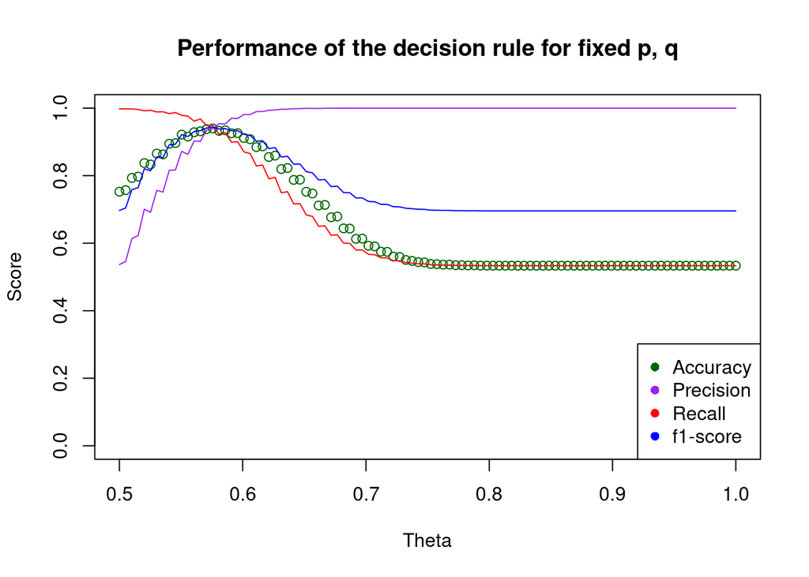

## Optimizing. We want the best performance!

Let’s take a step back first.

By the setup of the exercise, we do not have any real **hard constraints** which may indicate what could be better alternative in our decision process: - **is it better to have more false positive or false negatives?**, which translates to **who do we want to penalize more, the honest ones or the liars**?

Hint: *it’s a tradeoff*

We have the ability to choose which way to go, including what *metric* to choose to make our decision.

### Choosing $\alpha^*$ and $\beta^*$ - part 1.

In the exercise we need to set two levels, namely $\alpha^*$ and $\beta^*$ to be our *desired* false positive and false negative rates respectively. In our head we like to imagine it as *the gold standard* given by the *Supreme Commission for Decision Making of Sapienza University* to us, the professor, and we need to be able to get closer to it as possible. Of course a 0 for both would be perfect, but we’re afraid there’s a flaw since the beginning. We will do our best!

But how?

### A first attempt: the inverse approach

Suppose now, we want to choose our *maximize* accuracy! We have run our bit of simulation, and see what we can get with out iterative, non-numerical, optimization process. As stated in the title, this is the inverse approach. It’s basically taking the best performance we got and setting it as the *gold standard*. This is *NOT* how we need to approach it though, at least in this setup. Let’s take a look regardless:

```
## Optimizing by accuracy!
```

```
## (supposedly) Optimal Theta (decision threshold):  0.5757576
```

```
## (supposedly) Optimal alpha: 0.0326
```

```
## (supposedly) Optimal beta: 0.02753333
```

We could say though, given our $p$, $q$ and $N$. This is a nice result! In the off-chance you forgot the $N$ we set: it’s $N = 100$! Those students will be tossing those coins for a while. We can say that it’s a winning strategy though:

The more we throw those coins, the better we are able to differentiate between honest and liars.

Just for continuity, let’s see the performance of the *estimated* (I know I’m abusing syntax) best theta for our problem. We are going to do so visually, by introducing quickly the score and error functions.

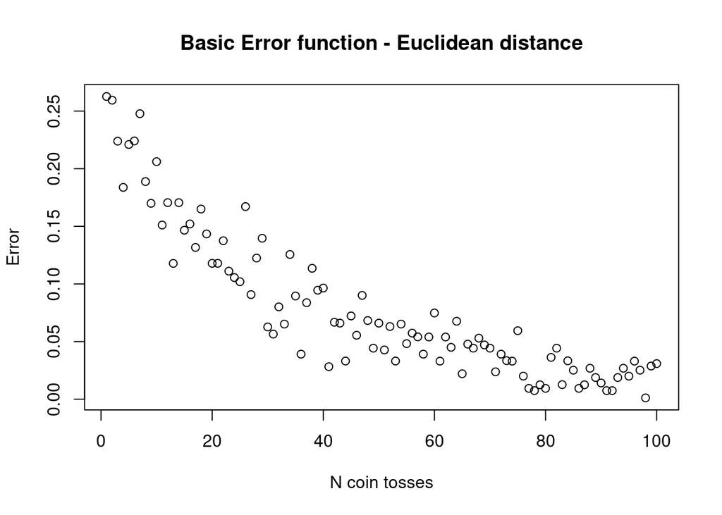

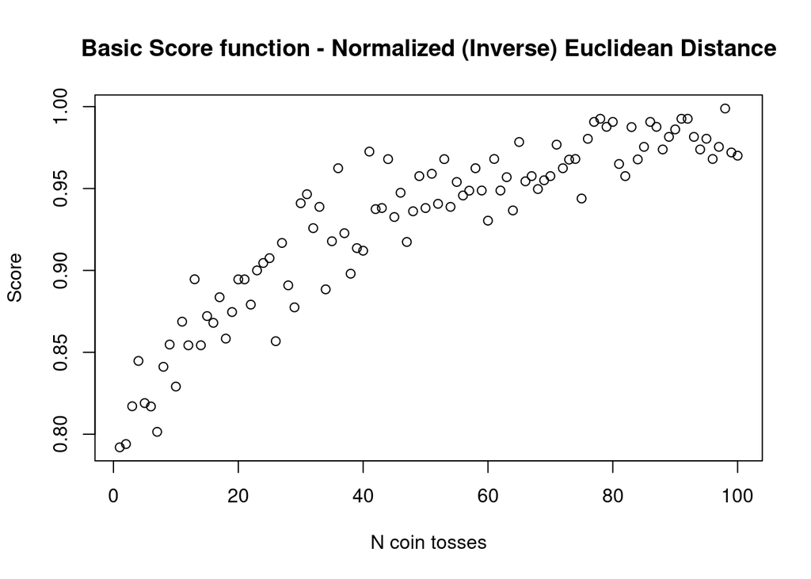

By the setup and the assumptions, we are considering $\hat{\alpha}, \hat{\beta}$ to be nothing more than points in $\mathrm{R}^2$, and we might get closer and closer to our target ratios $\alpha^*$ and $\beta^*$. Also $\alpha$ has the same weight as $\beta$ (1), which means we have no preference in getting better false positives rather than negatives and viceversa.

The $\hat{}$ (hat) notation has nothing to do with estimation for now, it just indicates a temporary step towards the optimum values - the alpha and betas which minimize distance or conversely maximize score. Enough said, let us move on.

### What if $\alpha^*$ is more important?

In this case, we assume that one of the two metrics is more important than the other. How do we express this? It could not be simpler…

$$\alpha^* \neq \beta^*$$
Whichever is higher in value will be less “important”! We can easily implement this in the score function. Will it make a difference? Surely! It will be reflected in the score functions.

## About: score functions

At the beginning of the homework we had a rough idea of what our score functions would measure, but no concrete idea if it had to be maximized or minimized. Surely for the word **score**, the higher the better, but during our lessons we encountered **loss** functions which in this case were more familiar to us.

After all, **minimizing** the “badness”, the discrepancy from the perfect parameters, seemed the more intuitive approach. But after consideration we decided to introduced the aforementioned Normalized Euclidean Distance, not really used in the literature, but intuitive enough for our purpose. In a formula:

$$\text{dist}(\hat{\alpha}, \hat{\beta}; \alpha^*,
\beta^*) = \frac{1}{\left( (\hat{\alpha} - \alpha^*)^2 + (\hat{\beta} -
\beta^*)^2 \right)^{\frac{1}{2}}} \in [0, 1]$$

### Extending for time elapsed $\tau$

In the second part of the exercise (1.2) we had to introduce **time** as a penalizing factor in our scores. So suppose we introduce a time constraint. How can we enforce it? Again, multiple ways of doing it.

A fun experiment we did was creating what we called the **redemption** function. Here’s the code:

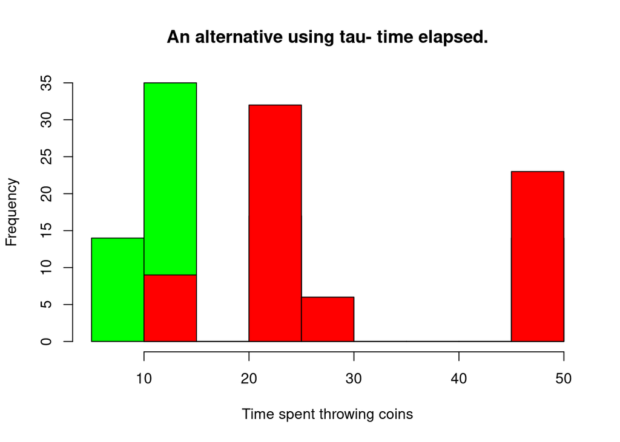

```r
decision_function_v1 = function(tosses_ratio, theta = 0.59){
  is_liar = 1 * (tosses_ratio >= theta)
  return (is_liar)
}

tp_v1 = sum(decision_function_v1(honest_throws) == 0)/n
tn_v1 = sum(decision_function_v1(liar_throws) == 1)/n
fp_v1 = sum(decision_function_v1(honest_throws) == 1)/n
fn_v1 = sum(decision_function_v1(liar_throws) == 0)/n



theta1 = 0.55 # Below this? All good!
theta2 = 0.60 # Below this? Check again with 10 throws..
theta3 = 0.63 # WHAT? Below this? 5 more chance.
theta4 = 0.67 # You get 1 more chance.
              # After 0.8 ratio you're out, liar....

N = 10 # The starting number of tosses per student. 30 seconds.
tau = 3  # seconds per throw

honest_throws = rbinom(n-k, size = N, prob = p)
honest_throws = cbind(honest_throws, honest_throws * tau)

liar_throws = rbinom(k, size = N, prob = q)
liar_throws = cbind(liar_throws, liar_throws * tau)


decision_function_v2 = function(results, prob){

  throws = results[,1]
  times = results[,2]
  is_liar = rep(NA, length(throws))

  alpha1 = theta1 * N # Set 4
  alpha2 = theta2 * N # thresholds
  alpha3 = theta3 * N # for the
  alpha4 = theta4 * N # experiment


  for(idx in 1:length(throws)){
    if(throws[idx] <= alpha1){
      is_liar[idx] = 0
    } else if(throws[idx] > alpha1 & throws[idx] <= alpha2){
      times[idx] = times[idx] + (tau * 10) # Time spent tossing 10 coins
      is_liar[idx] = decision_function_v1(rbinom(1, size = 10, prob = prob)/10, theta = 0.5)
    } else if(throws[idx] > alpha2 & throws[idx] <= alpha3){
      times[idx] = times[idx] + (tau * 5)  # Time spent tossing 5 coins
      is_liar[idx] = decision_function_v1(rbinom(1, size = 5, prob = prob)/5, theta = 0.5)
    } else if (throws[idx] > alpha1 & throws[idx] <= alpha2){
      times[idx] = times[idx] + (tau * 1)  # Time spent tossing 1 coin.
      is_liar[idx] = decision_function_v1(rbinom(1, size = 1, prob = prob), theta = 0.5)
    } else {
      is_liar[idx] = 1
    }
  }

  return(cbind(throws, times, is_liar))
}



honest_results = decision_function_v2(honest_throws, prob = p)
liar_results = decision_function_v2(liar_throws, prob = q)

hist(honest_results[,2], col = "green", xlab = "Time spent throwing coins", prob = F, main = "An alternative using tau- time elapsed.")
hist(liar_results[,2], add = T, col = "red", prob = F)
```

```r
tp = sum(honest_results[,3] == 0) / n
tn = sum(liar_results[,3] == 1) / n
fp = sum(honest_results[,3] == 1)/ n
fn = sum(liar_results[,3] == 0)/ n

cat("True positives:", tp, "True negatives:", tn, "False positives:", fp, "False negatives:", fn)
```

```
## True positives: 0.3666667 True negatives: 0.3933333 False positives: 0.1666667 False negatives: 0.07333333
```

Any easier way? Sure, for penalization you could use the time elapsed, call it $\tau$ as a penalizing variable (not constant as it is a function of the Bernoulli trials results) - put it at the denominator of a score function. Eventually, if you even consider it to be **exponentially** penalizing, you’ll reach a score of approximately zero.

How about **bounding** the time elapsed? How to make sure we don’t go over some time constraint? We thought that the best way to do so would be to enforce it via code. Anyways, about what we just said -

an example of a score penalized by the time elapsed $\tau$:

$$\text{score}(X_i, \alpha, \beta, N\ ; \alpha^*, \beta^*, \tau) =
\frac{1}{(\tau \cdot X_i)^2 \text(dist(\alpha, \beta, \alpha^*,
\beta^*))}$$

We quickly implemented it in the previous function which returned a score and error values:

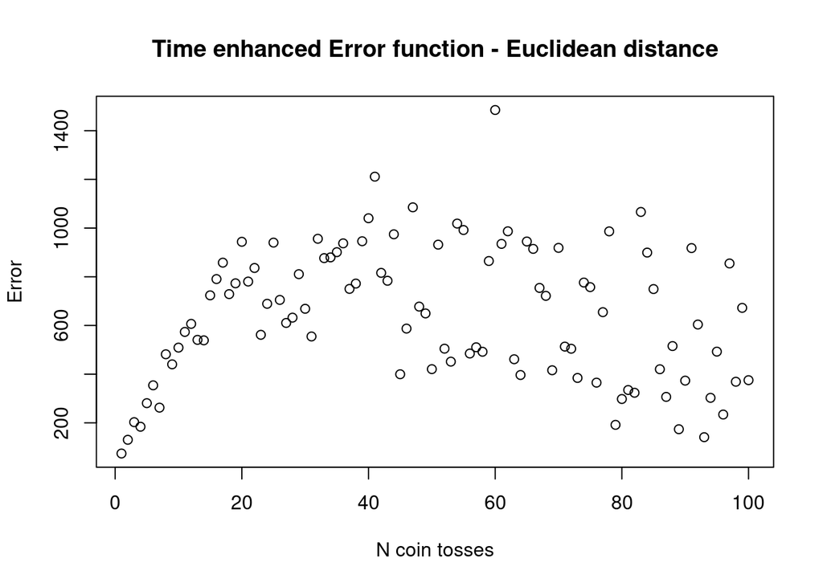

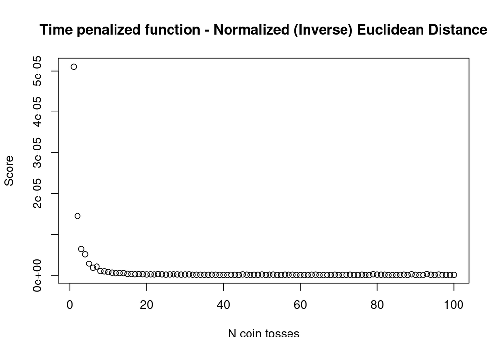

As we can see, even a linear combination of the various penalization heavily impacts both the score and the error functions. We have control over how much penalization we can **inflict** on our processes, we just need to be able to interpret it.

## About: decision rules

We already introduced one, the **thresholding** approach. Formalizing it:

$$\text{Decisional}(X_i\ ; \theta) = \mathbb{1}(X_i)_{X_i > \theta} ,
\hspace{.4cm} \theta \in [0,1]$$

Side note : the ‘$\mathbb{1}$’ is an indicator.

The previous one is probably better interpreted when seen in the context of the honest and liar plots, let us take a look!

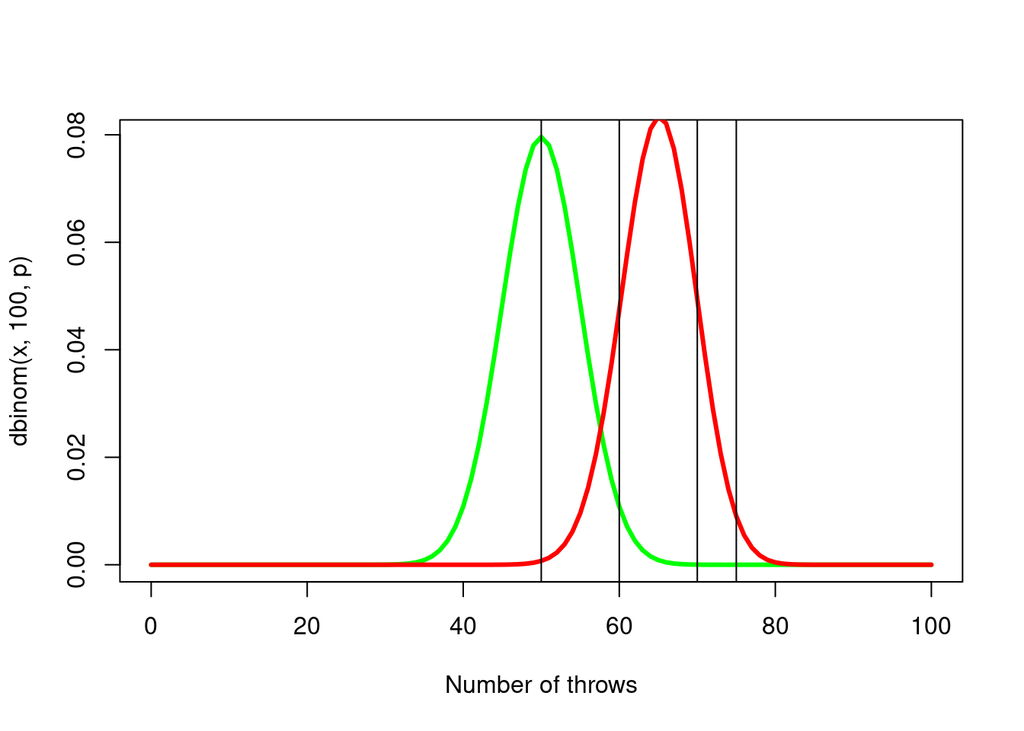

### Final comment

You might have noticed that the last results seem a bit “scattered away”. That is of course because we did not perform simulations - we know it brings more stable results, but just for the sake of explanations, we wanted to just save a bit of time!

## Exercise 2:

#### *2.1 Estimation of the quantile*

To pick an implementation of $\hat{f}_h(.)$ we first need to have a look into our distribution.

We know that X has a Beta($\alpha$,$\beta$) distribution and we consider $F_X(.)$ as the true population model.

```r
# Set the seed
set.seed(1234)

#Set up
N_samples = 1000

# Pick two different (alpha, beta) pairs
alpha_1 <- 1.5
beta_1 <- 3.5

# Generate random samples from a beta distribution - True scenario
true_population = rbeta(N_samples, shape1 = alpha_1, shape2 = beta_1)
```

After picking $\alpha$ = 1.5 and $\beta$ = 3.5, we plot the PDF $f_X(.)$ of the true population and the histograms.

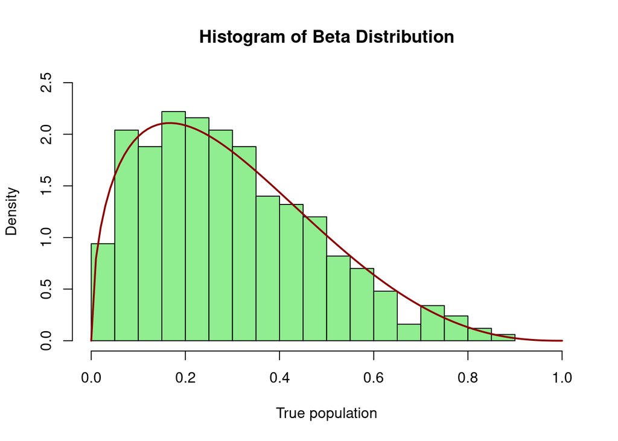

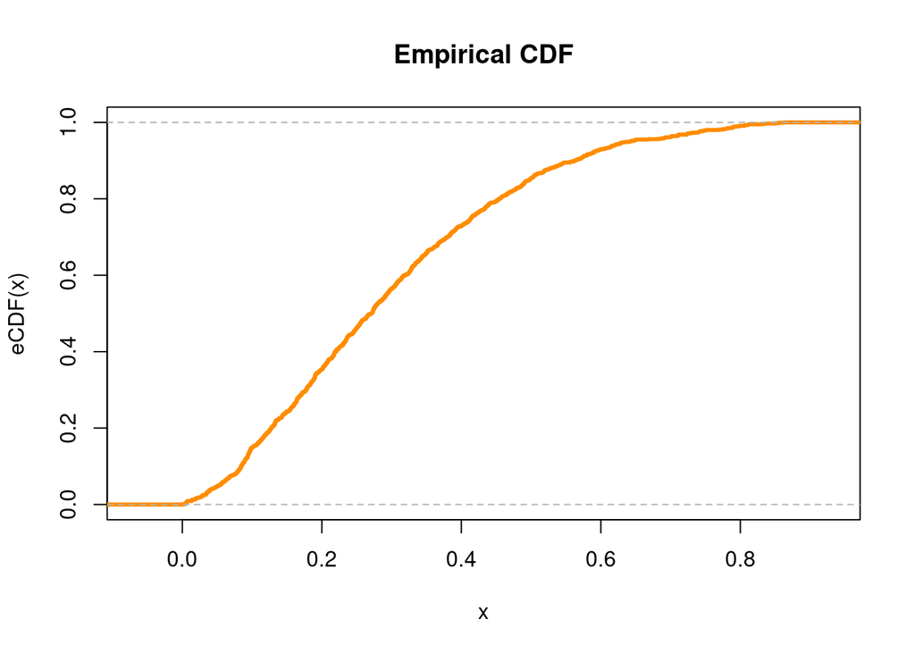

Now we consider $F_Y(.)$ as an approximation to $F_X(.)$ and the Kernel Density Estimator (KDE) $\hat{f}_h(.)$ for which we need to choose a bandwith h > 0.

```r
# Approximate scenario
alpha_2 <- 2
beta_2 <- 4.5

approx_population = rbeta(N_samples, shape1 = alpha_2, shape2 = beta_2)
```

After setting h = 0.3 we implement the Epanechnikov Kernel Density Estimator with the `density()` function, and we plot it:

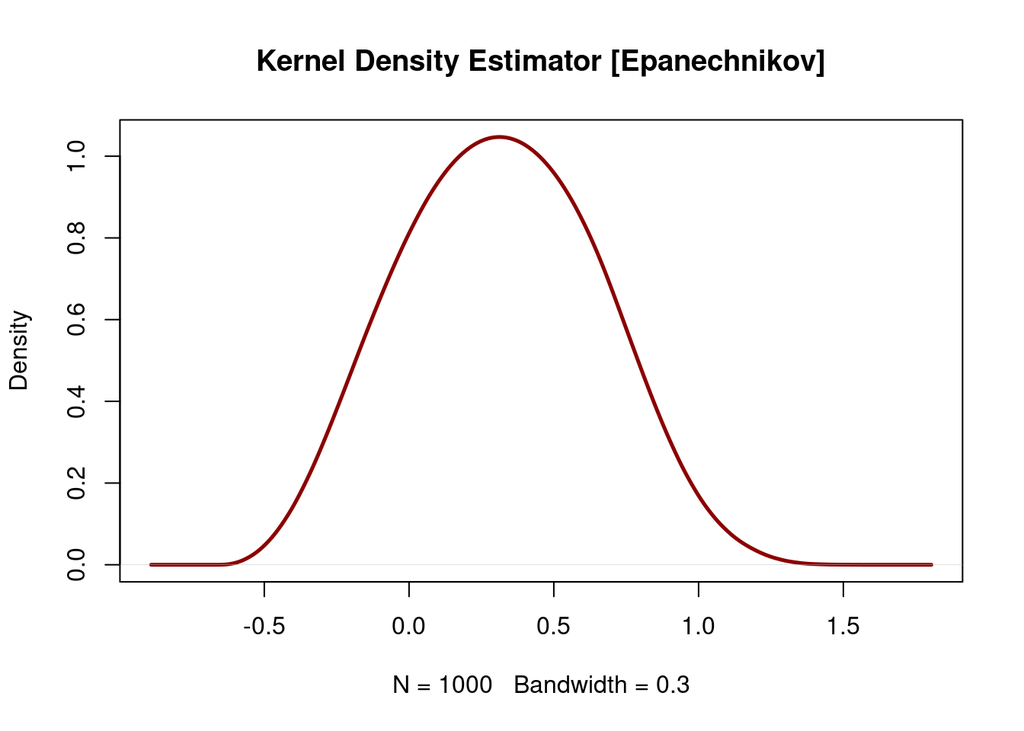

```r
# Set the bandwidth for the kernel density estimator
h = 0.3 # h has to be more than zero

KDE = density(approx_population, bw = h, kernel = "epanechnikov")
plot(KDE, main = "Kernel Density Estimator [Epanechnikov]", lwd = 2.5, col = "darkred")
```

Now we compute the approximated PDF and CDF:

```r
 approx_pdf <- approxfun(KDE$x, KDE$y, method = 'linear', yleft = 0, yright = 0)

 approx_cdf <- function(x, approx_pdf) {
  integrate(approx_pdf, -Inf, x)$value
}
```

And the estimation $\hat{F^{-1}}_h(.)$ of the quantile using the Epanechnikov-Kernel:

```r
compute_approx_quantile_epan_kernel <- function(x, h, z){
  KDE = density(x, bw = h, kernel = "epanechnikov")

  # Compute the approximate CDF values for each x
  x_values <- seq(min(KDE$x), max(KDE$x), length.out = length(KDE$x))
  cdf_values <- sapply(x_values, function(x) approx_cdf(x, approx_pdf))

  # Linear interpolation is performed to obtain a function, not just a set of points
  approx_pdf <- approxfun(KDE$x, KDE$y, method = 'linear', yleft = 0, yright = 0)

  # We are looking for the point where approx_cdf(x, approx_pdf) - z is zero,
  # and this point is approximately our desired quantile
  approx_quantile <- uniroot(function(x) approx_cdf(x, approx_pdf) - z, c(min(KDE$x), max(KDE$x)))$root
  return(list(x_values = x_values, cdf_values = cdf_values, approx_quantile = approx_quantile))
}
```

#### *2.2 Compute the Wasserstein-Distance*

Compute Wasserstein-Distance, looking for the largest bandwidth h such that:

$$W_{L_{1},1}(f,\hat{f_h})=\left(\int_{0}^{1}
|F^{-1}(z)-\hat{F^{-1}_h}(z) \,| dz\right) \le \epsilon$$
Let’s compute the first element, $F^{-1}(z)$

```r
compute_true_quantile <- function(z){
  qbeta(z, alpha_1, beta_1)
}
```

that we will use to compute the Wasserstein-Distance formula implemented by hand:

```r
wass_distance <- function(z, approx_quantile) {
  return(integrate(function(z) abs(compute_true_quantile(z) - approx_quantile), 0, 1)$value)
}
```

Now let’s search, through a series of plots, for the largest bandwidth h in a range of values that we set from 0.05 to 1.5. These plots show both the cdf with the true and estimated quantile and also the correspondent h and Wasserstein-Distance value on the top of the graph:

```r
compute_largest_bandwidth_h <- function(z, epsilon){
  max_h <- NULL
  x_values <- seq(min(approx_population), max(approx_population), length.out = 100)

  for (h_i in h){
    result <- compute_approx_quantile_epan_kernel(approx_population, h_i, z)
    x_values <- result$x_values
    cdf_values <- result$cdf_values
    approx_quantile <- result$approx_quantile
    wass_distance_value <- wass_distance(z, approx_quantile)

    # Visualization
    print(paste("h_i:", h_i, "approx_quantile:", round(approx_quantile,4),
                "true_quantile:", round(compute_true_quantile(z), 4)))
    print(paste("Wasserstein-Distance:", round(wass_distance_value, 4)))

    plot_distance(x_values, cdf_values, compute_true_quantile(z), approx_quantile, h_i, wass_distance_value)

    if (wass_distance_value <= epsilon) {
        max_h <- h_i
    }
    else{
      break
    }
  }
    return(max_h)
}
```

We will now conduct some tests varying both $\epsilon$ and the bandwidth h to see how they influence each other and the Wasserstain-Distance.

**Test for $\epsilon$ = 0.15**

```
## [1] "h_i: 0.05 approx_quantile: 0.2957 true_quantile: 0.2718"
## [1] "Wasserstein-Distance: 0.1533"
```

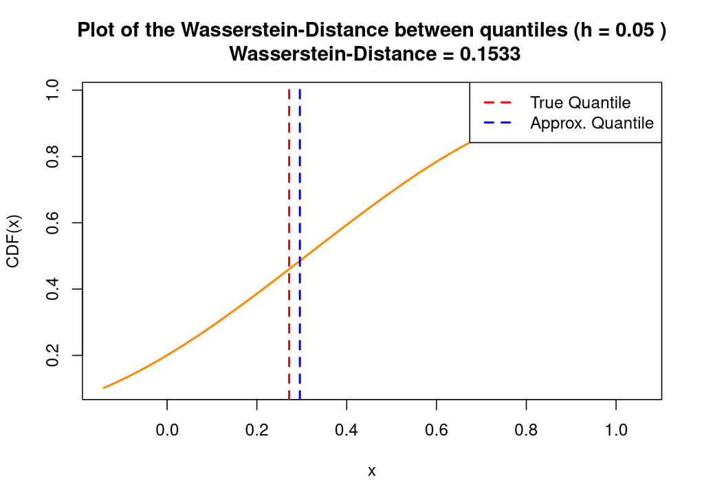

```
## Largest bandwidth h:
```

**Test for $\epsilon$ = 0.2**

```
## [1] "h_i: 0.05 approx_quantile: 0.3429 true_quantile: 0.3264"
## [1] "Wasserstein-Distance: 0.1615"
```

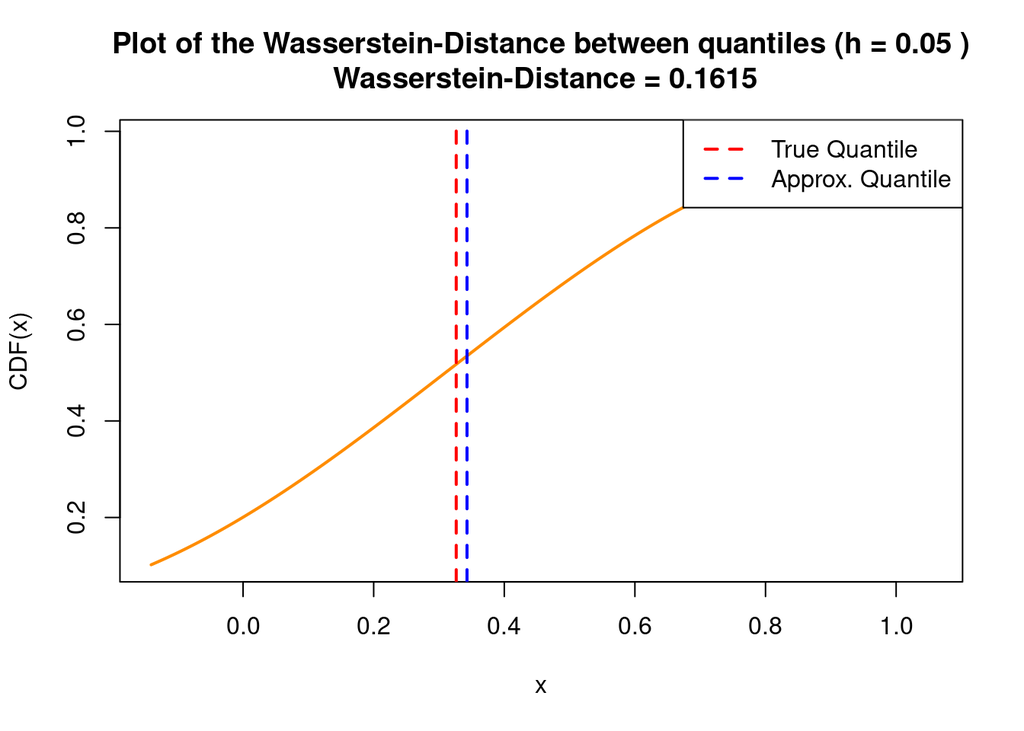

```
## [1] "h_i: 0.25 approx_quantile: 0.3916 true_quantile: 0.3264"
## [1] "Wasserstein-Distance: 0.1778"
```

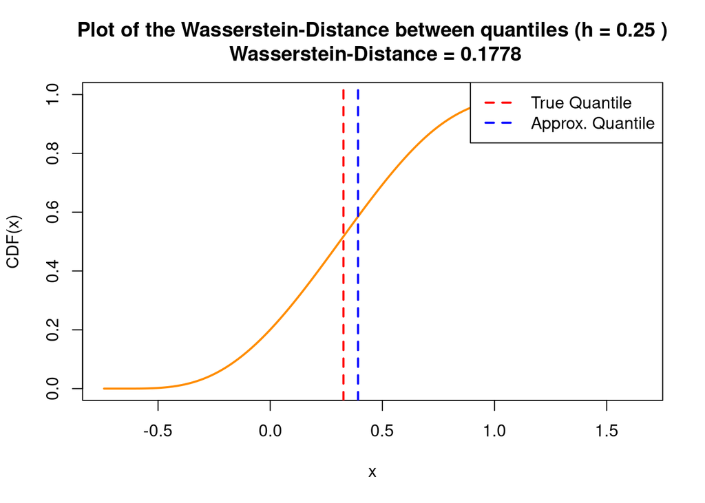

```
## [1] "h_i: 0.45 approx_quantile: 0.4496 true_quantile: 0.3264"
## [1] "Wasserstein-Distance: 0.2062"
```

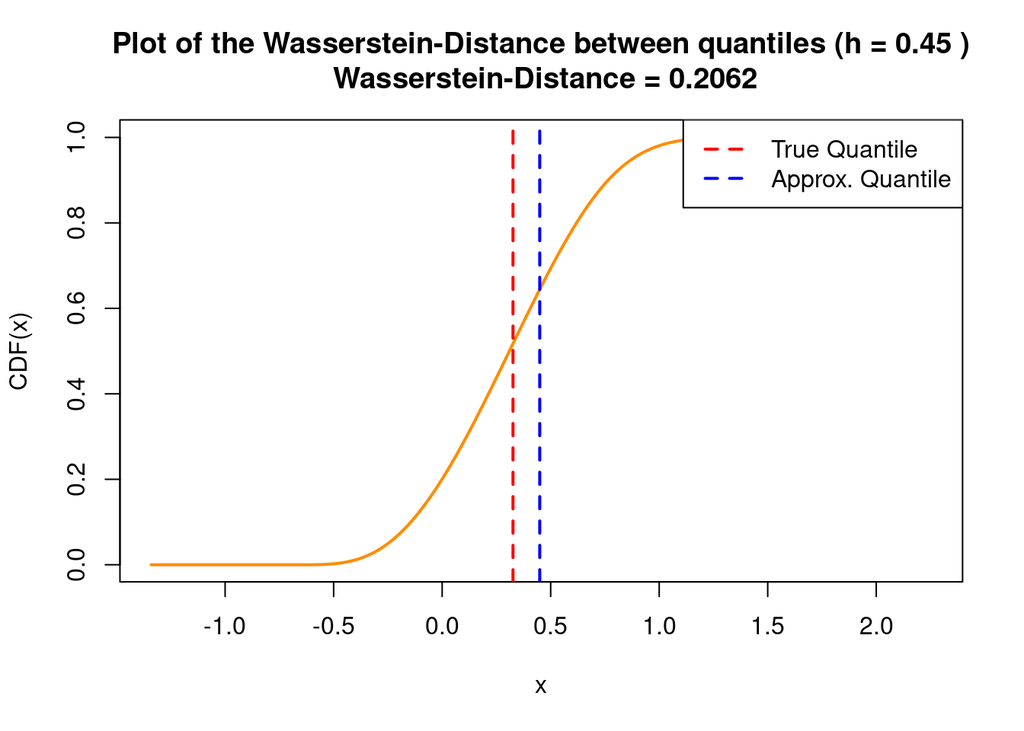

```
## Largest bandwidth h: 0.25
```

**Test for $\epsilon$ = 0.5**

```
## [1] "h_i: 0.05 approx_quantile: 0.3429 true_quantile: 0.3264"
## [1] "Wasserstein-Distance: 0.1615"
```

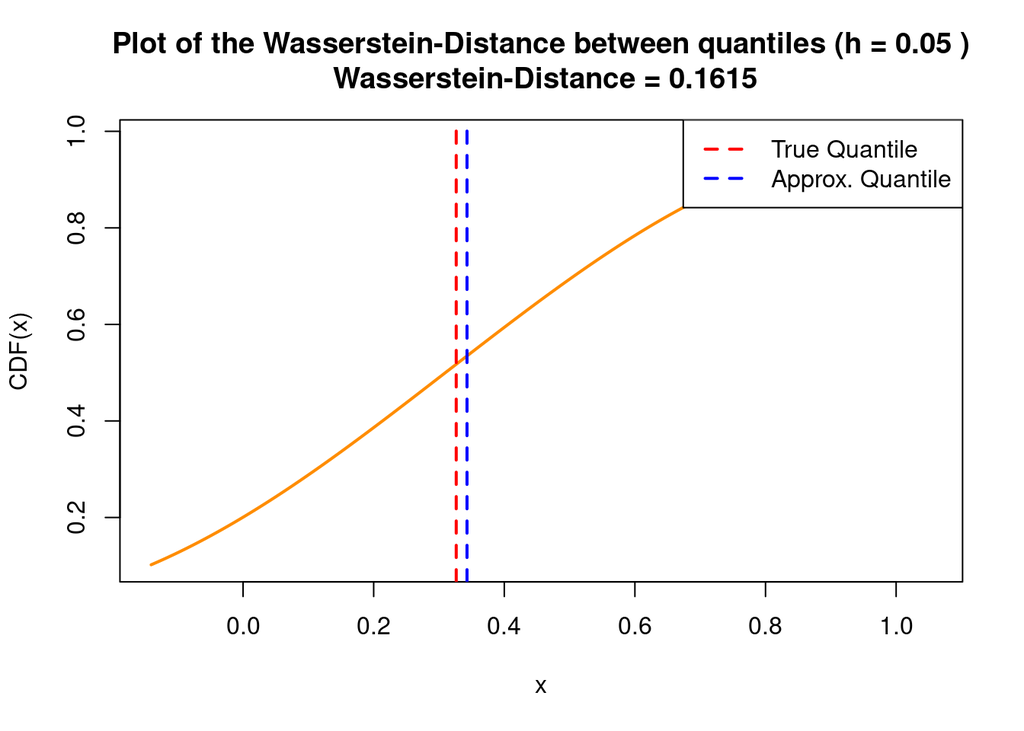

```
## [1] "h_i: 0.25 approx_quantile: 0.3916 true_quantile: 0.3264"
## [1] "Wasserstein-Distance: 0.1778"
```

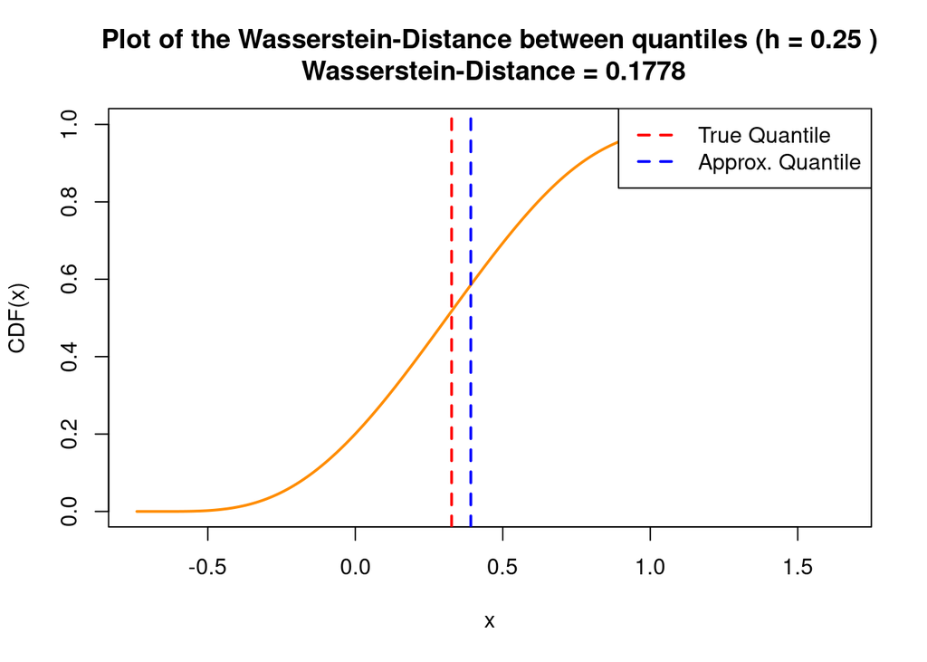

```
## [1] "h_i: 0.45 approx_quantile: 0.4496 true_quantile: 0.3264"
## [1] "Wasserstein-Distance: 0.2062"
```

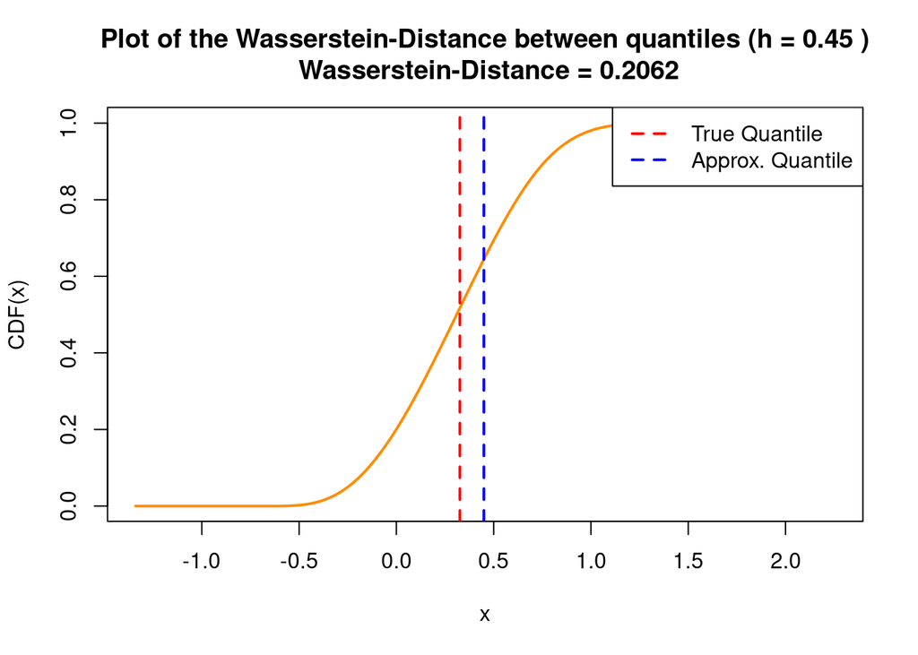

```
## [1] "h_i: 0.65 approx_quantile: 0.5084 true_quantile: 0.3264"
## [1] "Wasserstein-Distance: 0.2435"
```

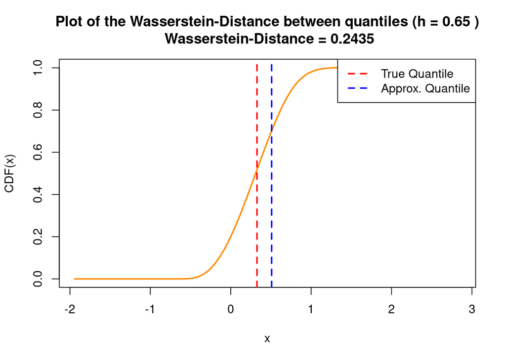

```
## [1] "h_i: 0.85 approx_quantile: 0.5677 true_quantile: 0.3264"
## [1] "Wasserstein-Distance: 0.2879"
```

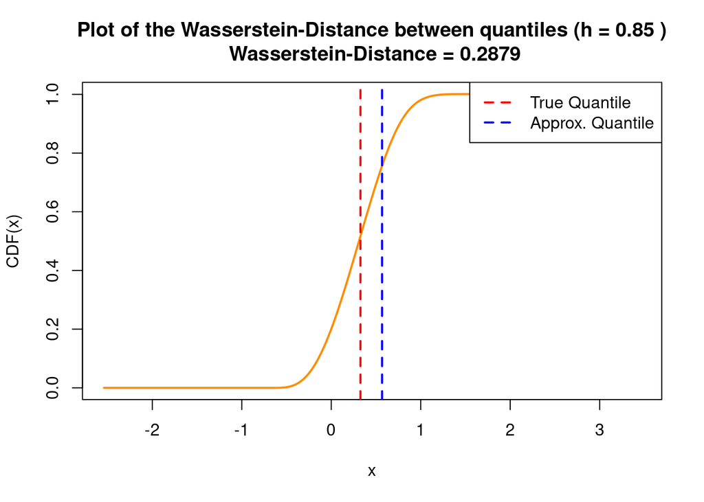

```
## [1] "h_i: 1.05 approx_quantile: 0.6271 true_quantile: 0.3264"
## [1] "Wasserstein-Distance: 0.3377"
```

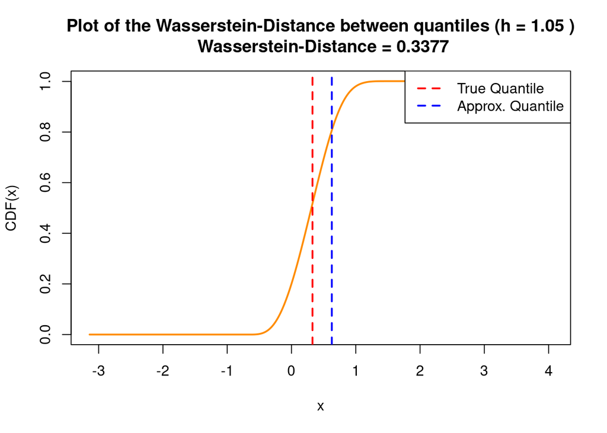

```
## [1] "h_i: 1.25 approx_quantile: 0.6865 true_quantile: 0.3264"
## [1] "Wasserstein-Distance: 0.3915"
```

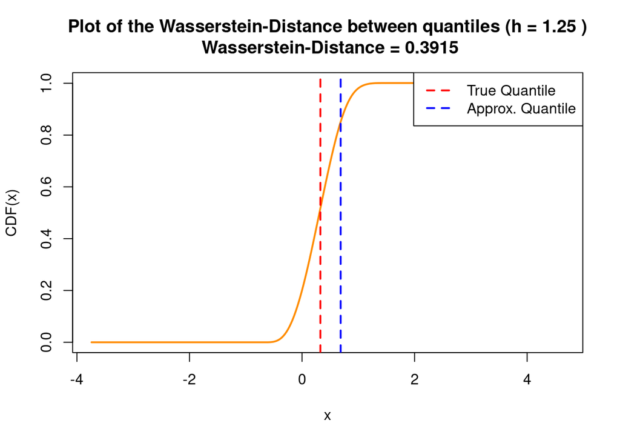

```
## [1] "h_i: 1.45 approx_quantile: 0.746 true_quantile: 0.3264"
## [1] "Wasserstein-Distance: 0.448"
```

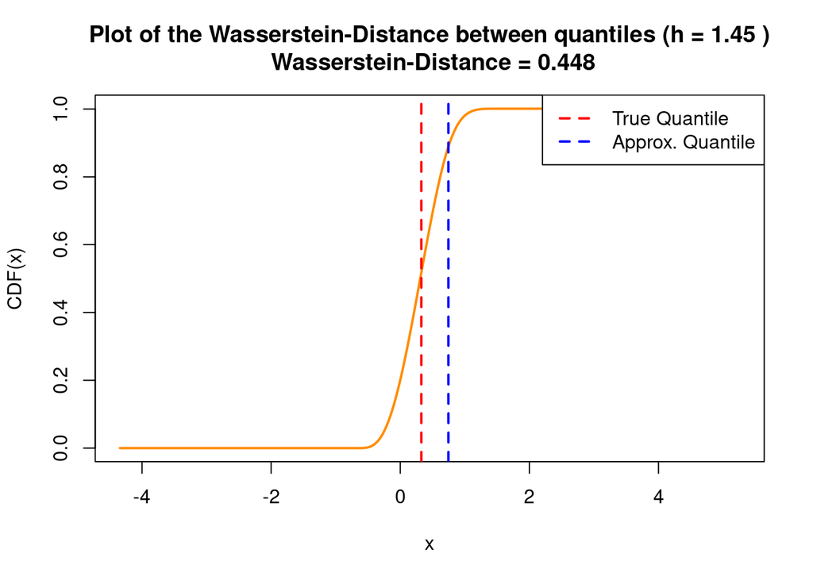

```
## Largest bandwidth h: 1.45
```

We know that a small bandwidth h leads to undersmoothing and a large bandwidth leads to oversmoothing, and we also know that the smaller the $\epsilon$ the more accurate the distance, but it may take more time computationally.

From the 3 sets of simulations we made (for $\epsilon$ = 0.15, $\epsilon$ = 0.2, and $\epsilon$ = 0.5) we can see that the more we increase $\epsilon$ the more the distance and the bandwidth h increase. This means that the distance measure will become less sensitive to small differences in the distribution, effectively ignoring small fluctuations. Also, we can observe that for values of $\epsilon$ < 0.2, the distance is actually > $\epsilon$ so that cases are not valid. Then we can assert that this distance actually has a lower bound.

If we are looking for the largest bandwidth h such that

$$W_{L_{1},1}(f,\hat{f_h})=\left(\int_{0}^{1}
|F^{-1}(z)-\hat{F^{-1}_h}(z) \,| dz\right) \le \epsilon$$
from the simulation we made, we can conclude that to achieve this result we have to decrease the bandwidth.

Decreasing h and consequentially getting a smaller $\epsilon$, also leads to a smaller distance. This means that the two quantiles we are comparing, the one from the true population and the approximate one, are almost the same.

#### **References:**

https://aakinshin.net/posts/kde-bw/ https://en.wikipedia.org/wiki/Kernel_density_estimation